# Visualizations with ggplot

Julia Tulloh

2020-09-20

# 1 Visualizing CDC Covid 19 Data

There are well over 3 million entries of individual, de-identified patient data. Due to the size of the file,`vroom` function is used to load the table.

```r
# URL link to CDC to download data
url <- "https://data.cdc.gov/api/views/vbim-akqf/rows.csv?accessType=DOWNLOAD"

covid_data <- vroom(url)%>%
  clean_names()
library(scales)
```

We want to calculate and visualize COVID-19 death rates by sex, and by whether the patient had comorbidities.

```r
#Preparing the data - filtering by sex, selecting relevant columns, calculating death rates.
covid_death_rate_comorbidities<-covid_data %>%
  filter(sex %in% c('Male','Female'),!age_group %in% c('Unknown',NA),medcond_yn %in% c('Yes','No'),death_yn %in% c('Yes','No')) %>% #filter for relevant values
  select(sex,age_group,death_yn,medcond_yn) %>%
  group_by(sex,age_group,medcond_yn) %>%
  summarize(death=sum(death_yn=="Yes"),total=n()) %>%
  mutate(death_rate=(death/total*100)) %>%
  select(sex,age_group,medcond_yn,death_rate)

new_labels<-c('Yes'='With Comorbidities','No'='Without Comorbidities')
```

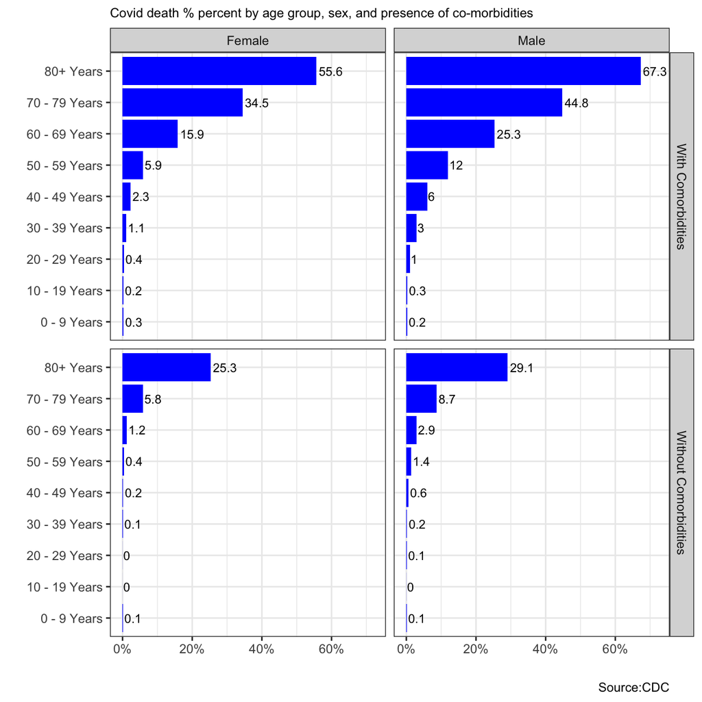

```r
#plotting the data
ggplot(covid_death_rate_comorbidities,aes(x=death_rate,y=age_group))+
geom_col(fill='blue')+
facet_grid(medcond_yn~sex,as.table=FALSE,labeller=labeller(medcond_yn=new_labels))+
  theme_bw()+
  geom_text(aes(label=round(death_rate,digits=1)),hjust=-0.1,size=3)+
  expand_limits(x=c(0,72))+
  scale_x_continuous(labels=label_percent(scale=1))+
  labs(title='Covid death % percent by age group, sex, and presence of co-morbidities',x='',y='',caption='Source:CDC')+
  theme(plot.title=element_text(size=9))
```

Based on the plot above, it seems that in most age groups women are dying at lower rates. In addition those with comorbidities are dying at higher rates.

Now we want to examine how the death rates differ if a patient was admitted to the ICU.

```r
#Preparing the data
covid_death_rate_icu<-covid_data %>%
  filter(sex %in% c('Male','Female'),!age_group %in% c('Unknown',NA),icu_yn %in% c('Yes','No'),death_yn %in% c('Yes','No')) %>%
  select(sex,age_group,death_yn,icu_yn) %>%
  group_by(sex,age_group,icu_yn) %>%
  summarize(death=sum(death_yn=="Yes"),total=n()) %>%
  mutate(death_rate=(death/total*100)) %>%
  select(sex,age_group,icu_yn,death_rate)

new_labels_icu<-c('Yes'='Admitted to ICU','No'='No ICU')
```

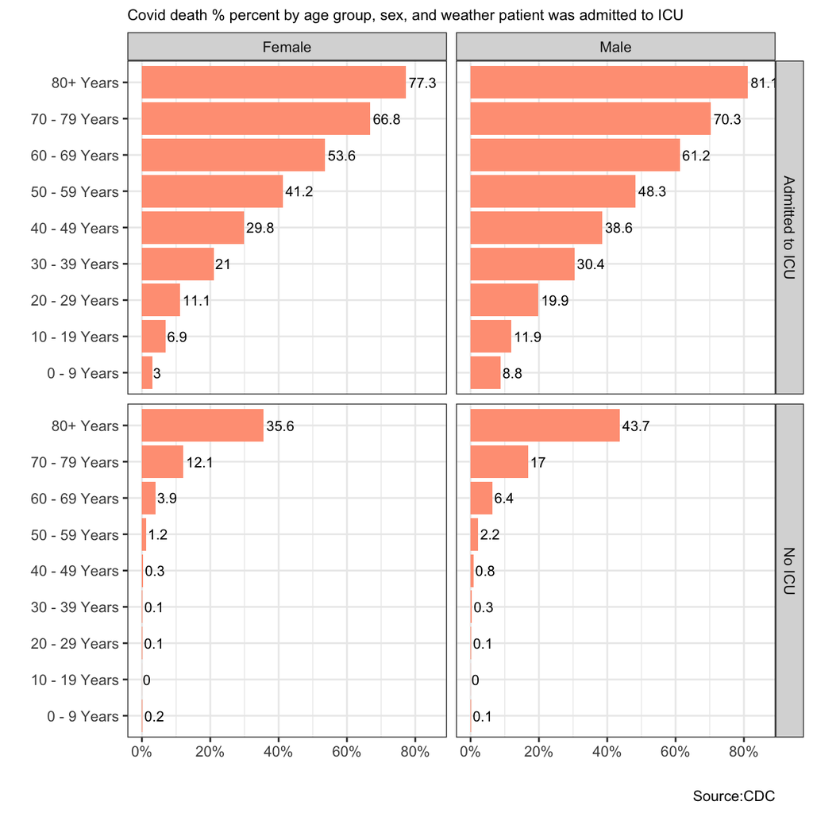

```r
#Building the plot
ggplot(covid_death_rate_icu,aes(x=death_rate,y=age_group))+
geom_col(fill='#ffa084')+
facet_grid(icu_yn~sex,as.table=FALSE,labeller=labeller(icu_yn=new_labels_icu))+
  theme_bw()+
  geom_text(aes(label=round(death_rate,digits=1)),hjust=-0.1,size=3)+
  expand_limits(x=c(0,85))+
  scale_x_continuous(labels=label_percent(scale=1))+
  labs(title='Covid death % percent by age group, sex, and weather patient was admitted to ICU',x='',y='',caption='Source:CDC')+
  theme(plot.title=element_text(size=9))
```

Based on the plot above, especially in older age groups, if a patient is admitted to the ICU, they have much higher death rates.

# 2 Visualizing excess bike rentals in TfL bike sharing

First we load the most updated data on TfL bike rentals from data.london.gov.uk.

We want to examine how much the monthly rentals deviated from the monthly average each year.

First, we prep the data.

```r
# change dates to get year, month, and week
bike <- bike0 %>%
  clean_names() %>%
  rename (bikes_hired = number_of_bicycle_hires) %>%
  mutate (year = year(day),
          month = lubridate::month(day, label = TRUE),
          week = isoweek(day))

bike_filtered <- bike %>%
                  filter(year %in% c(2015: 2020)) %>%
                  group_by(year, month) %>%
                  summarise(avgMonth=mean(bikes_hired))

bike_monthly_average <- bike_filtered %>%
                  filter(year %in% c(2015: 2019)) %>%
                  group_by(month) %>%
                  summarise(year_avgMonth=mean(avgMonth))

# Change month to numeric
bike_filtered$month <- as.numeric(bike_filtered$month)

# Change month to numeric
bike_monthly_average$month <- as.numeric(bike_monthly_average$month)


bike_left_join_1 <-left_join(bike_filtered,bike_monthly_average, by="month")

bike_left_join_2 <- bike_left_join_1 %>%
  mutate(diff_month = avgMonth-year_avgMonth)


bike_left_join_2
```

```
## # A tibble: 68 x 5
## # Groups:   year [6]
##     year month avgMonth year_avgMonth diff_month
##    <dbl> <dbl>    <dbl>         <dbl>      <dbl>
##  1  2015     1   18828.        20259.     -1431.
##  2  2015     2   19617.        21573.     -1956.
##  3  2015     3   22625.        23115.      -490.
##  4  2015     4   27951.        28230.      -278.
##  5  2015     5   29031.        32422.     -3391.
##  6  2015     6   34659.        35262.      -604.
##  7  2015     7   36607.        37809.     -1202.
##  8  2015     8   33643.        34243.      -600.
##  9  2015     9   30114.        32433.     -2319.
## 10  2015    10   28560.        29900.     -1339.
## # … with 58 more rows
```

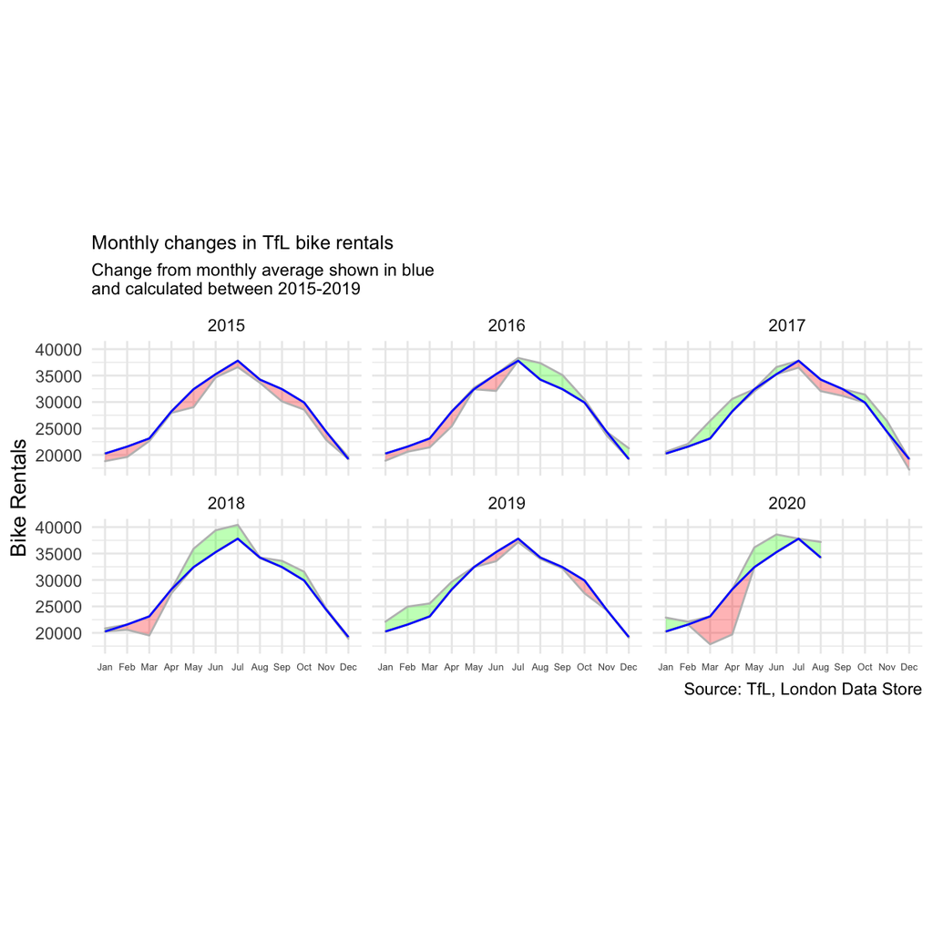

```r
#plotting the data
bike_left_join_2$month <- as.numeric(bike_left_join_2$month)
bike_left_join_2$month <- as.factor(bike_left_join_2$month)

ggplot(data=bike_left_join_2, aes(x=month , y=year_avgMonth, group=1)) + facet_wrap(~year) +
labs(x=NULL, y="Bike Rentals", caption="Source: TfL, London Data Store", title="Monthly changes in TfL bike rentals", subtitle= "Change from monthly average shown in blue \nand calculated between 2015-2019") + theme_minimal(base_family="Arial") + theme (plot.title = element_text(size=10), plot.subtitle = element_text(size=9))+
  geom_ribbon(aes(ymin = year_avgMonth + if_else(diff_month < 0, diff_month, 0),
                  ymax = year_avgMonth), color ="grey", fill = "red", alpha = 0.3) +
  geom_ribbon(aes(ymin = year_avgMonth,
                  ymax = year_avgMonth + if_else(diff_month > 0, diff_month, 0)),color ="grey", fill = "green", alpha = 0.3)+ theme(aspect.ratio=0.5) + theme(axis.text.x= element_text(size=5)) +
  scale_x_discrete(labels=c("Jan", "Feb", "Mar", "Apr", "May", "Jun", "Jul", "Aug", "Sep", "Oct", "Nov", "Dec"))+ geom_line(color="blue")
```

As we can see in the plot above, 2020 has been an unusual year. March and April are significantly below the monthly average, likely due to the government imposed lockdowns.

The second graph we will create looks at percentage changes from the expected level of weekly rentals. The two grey shaded rectangles correspond to the second (weeks 14-26) and fourth (weeks 40-52) quarters.

For both of these graphs, we calculate the expected number of rentals per week or month between 2015-2019 and then, see how each week/month of 2020 compares to the expected rentals. More specifically, we use the calculation `excess_rentals = actual_rentals - expected_rentals`.

We used means as expected rentals as the data is approximately normally distributed.

```r
bike_filtered_week <- bike %>%
                  filter(year %in% c(2015: 2020)) %>%
                  group_by(year, week) %>%
                  summarise(avgWeek_filtered_week=mean(bikes_hired))

bike_weekly_average <- bike_filtered_week %>%
                  filter(year %in% c(2015: 2019)) %>%
                  group_by(week) %>%
                  summarise(avgWeek_weekly_average=mean(avgWeek_filtered_week))

bike_joined_full <- left_join(bike_filtered_week, bike_weekly_average, by = "week")


bike_joined_full_2 <- bike_joined_full %>%
  mutate(excessrentalspercent = (avgWeek_filtered_week - avgWeek_weekly_average)*100/avgWeek_weekly_average)
```

Finally, we produce the plots.

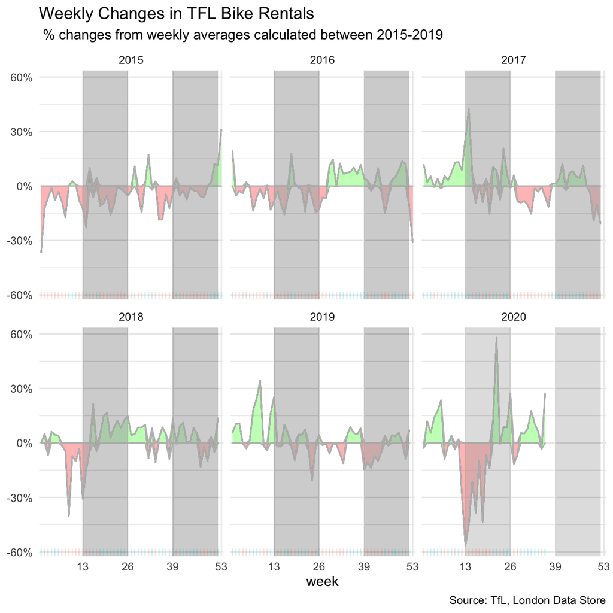

```r
ggplot(bike_joined_full_2, aes(x=week, y=excessrentalspercent)) +
  labs(title= "Weekly Changes in TFL Bike Rentals", subtitle=" % changes from weekly averages calculated between 2015-2019", x="week", y=NULL, caption="Source: TfL, London Data Store") +
  facet_wrap(~year)+ geom_line(fill="black") +
  theme_minimal() +
  geom_ribbon(aes(ymin = excessrentalspercent - if_else(excessrentalspercent < 0, excessrentalspercent, 0),
                  ymax = excessrentalspercent), color ="grey", fill = "red", alpha = 0.3) +
  geom_ribbon(aes(ymin = excessrentalspercent,
                  ymax = excessrentalspercent - if_else(excessrentalspercent > 0, excessrentalspercent, 0)),color ="grey", fill = "green", alpha = 0.3) +
   scale_x_discrete(limits = c(13, 26, 39, 53)) +
  geom_rect(xmin=13, xmax=26, ymin=-150, ymax=150, fill="grey", alpha=0.01) +geom_rect(xmin=39, xmax=52,ymin=-150, ymax=150,
                                                                                          fill="grey", alpha=0.01) +
  geom_rug(sides="b", aes(colour=ifelse(excessrentalspercent > 0, "red", "green")), alpha=0.2) +
  theme(legend.position='none') +
  scale_y_continuous(labels = function(x) paste0(x, "%"))
```

# 3 Visualizing 2016 California Contributors

In this project, we want to visualize campaign contributions in California in the 2016 election.

We start with loading the data.

```r
CA_contributors_2016 <- vroom::vroom(here::here("CA_contributors_2016.csv")) # Loading Contribution Data Set

Zip_codes_full <- vroom::vroom(here::here("zip_code_database.csv")) # Loading US zipcode data set

glimpse(CA_contributors_2016) # inspecting the data sets
```

```
## Rows: 1,292,843
## Columns: 4
## $ cand_nm           <chr> "Clinton, Hillary Rodham", "Clinton, Hillary Rodham…
## $ contb_receipt_amt <dbl> 50.0, 200.0, 5.0, 48.3, 40.0, 244.3, 35.0, 100.0, 2…
## $ zip               <dbl> 94939, 93428, 92337, 95334, 93011, 95826, 90278, 90…
## $ contb_date        <date> 2016-04-26, 2016-04-20, 2016-04-02, 2016-11-21, 20…
```

```r
glimpse(Zip_codes_full) # inspecting the data sets
```

```
## Rows: 42,522
## Columns: 16
## $ zip                  <chr> "00501", "00544", "00601", "00602", "00603", "00…
## $ type                 <chr> "UNIQUE", "UNIQUE", "STANDARD", "STANDARD", "STA…
## $ primary_city         <chr> "Holtsville", "Holtsville", "Adjuntas", "Aguada"…
## $ acceptable_cities    <chr> NA, NA, NA, NA, "Ramey", "Ramey", NA, NA, NA, NA…
## $ unacceptable_cities  <chr> "I R S Service Center", "Irs Service Center", "C…
## $ state                <chr> "NY", "NY", "PR", "PR", "PR", "PR", "PR", "PR", …
## $ county               <chr> "Suffolk County", "Suffolk County", "Adjuntas", …
## $ timezone             <chr> "America/New_York", "America/New_York", "America…
## $ area_codes           <dbl> 631, 631, 787939, 787, 787, NA, NA, 787939, 787,…
## $ latitude             <dbl> 40.8, 40.8, 18.2, 18.4, 18.4, 18.4, 18.4, 18.2, …
## $ longitude            <dbl> -73.0, -73.0, -66.7, -67.2, -67.2, -67.2, -67.2,…
## $ world_region         <chr> NA, NA, NA, NA, NA, NA, NA, NA, NA, NA, NA, NA, …
## $ country              <chr> "US", "US", "US", "US", "US", "US", "US", "US", …
## $ decommissioned       <dbl> 0, 0, 0, 0, 0, 0, 0, 0, 0, 0, 0, 0, 0, 0, 0, 0, …
## $ estimated_population <dbl> 384, 0, 0, 0, 0, 0, 0, 0, 0, 0, 0, 0, 0, 0, 0, 0…
## $ notes                <chr> NA, NA, NA, NA, NA, NA, NA, NA, NA, "no NWS data…
```

```r
Zip_codes <- Zip_codes_full %>% #getting rid of unessecary data, only keeping the zip code and corresponding city
  select(zip, primary_city)
```

Merging the two data sets:

While glimpsing at the two data sets, we noticed that the while both data set have the column, “zip”, one is saved as a double and one as a character.

In order to merge the two with left_join, we have to change one of the two. Here we change the zip variable in the CA_contributors_2016 data set from double to character

```r
CA_contributors_2016_amd <- CA_contributors_2016 %>%
  mutate(zip = as.character(zip))

# We can now merge the two datasets

new_dataset <- left_join(CA_contributors_2016_amd, Zip_codes, by = "zip") #joining the two data set using the variable "zip" which is present in both datasets
glimpse(new_dataset)
```

```
## Rows: 1,292,843
## Columns: 5
## $ cand_nm           <chr> "Clinton, Hillary Rodham", "Clinton, Hillary Rodham…
## $ contb_receipt_amt <dbl> 50.0, 200.0, 5.0, 48.3, 40.0, 244.3, 35.0, 100.0, 2…
## $ zip               <chr> "94939", "93428", "92337", "95334", "93011", "95826…
## $ contb_date        <date> 2016-04-26, 2016-04-20, 2016-04-02, 2016-11-21, 20…
## $ primary_city      <chr> "Larkspur", "Cambria", "Fontana", "Livingston", "Ca…
```

As we can see we have know successfully added the city to each contribution.

Filtering for the relevant candidates:

```r
new_dataset_1 <- new_dataset %>%
  filter(cand_nm == "Clinton, Hillary Rodham" | cand_nm == "Trump, Donald J.") #filter for Trump and Clinton
```

```r
library(tidytext)

top_10_cities_orderd <- new_dataset_1 %>%
  group_by(primary_city, cand_nm) %>% #grouping data by candidate and city
  summarise(contribution = sum(contb_receipt_amt)) %>%  # adding up the contributions for each candidate and city
  ungroup() %>%
  group_by(cand_nm) %>% #grouping data by candidate only
  top_n(10, contribution) %>% #selecting the top contributing cities for each group
  ungroup() %>%
  mutate(primary_city = reorder_within(primary_city, contribution, cand_nm)) #reordering the cities by contribution for each candidate
```

Plotting the data:

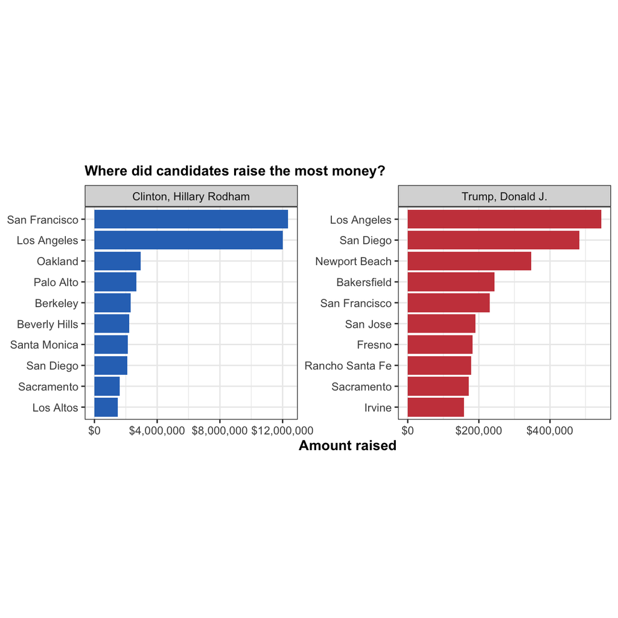

```r
party_colors <- c("#2E74C0", "#CB454A") #color codes for the ggplot

final_plot <- ggplot(top_10_cities_orderd,
                     aes(x = contribution, #show contribution on x axis
                         y = reorder(primary_city, contribution), #shows cities on y axis, orderd by contribution
                         fill = cand_nm)) +
  geom_col(show.legend = FALSE) + #hides the legend
  scale_x_continuous(labels = scales::dollar) + #show y-axis values in dollar
  theme_bw() + #changes the grid theme
  facet_wrap(~cand_nm, scales = "free") + #shows data in two facets, one for each candidate
  scale_fill_manual(values = party_colors) + #colors the two facets in blue and red
  labs(x = "Amount raised", y = NULL, subtitle = "Where did candidates raise the most money?") + #formats lables and plot titles
  theme(plot.subtitle = element_text(face = "bold")) + #makes plot title bold
  theme(axis.title.x = element_text(face = "bold")) + #makes x-axis title bold
  scale_y_reordered() + #necessary to properly show y-axis lables when "reorder_within" function is used
  theme(aspect.ratio = 1) + #changes facets to appear as squares
  NULL

final_plot
```

Based on the plot above, Hillary Clinton’s fundraising in California was concentrated in LA and SF. Overall Clinton raised more money than Trump in California.